# Supervised Learning Practical 2: Cross-Validation

Machine Learning for Health Research — Teaching Materials

August 20, 2025

# Learning Objectives

By the end of this practical you will be able to:

1. **Explain the limitations of a single train/test split** - Understand why one split isn’t enough for reliable model evaluation
2. **Configure and run *k*-fold cross-validation** - Learn how to set up robust model validation using the **caret** package
3. **Train and compare multiple models** - Practice training different algorithms on the same resampling splits for fair comparison
4. **Evaluate models using ROC AUC** - Learn when and how to use ROC AUC for imbalanced data (Optional)

# Setup

## Load Libraries and Data

```r
# ============================================================================
# LOADING REQUIRED LIBRARIES
# ============================================================================
# tidyverse: Collection of R packages for data science (includes ggplot2, dplyr, etc.)
library(tidyverse)

# caret: Classification And REgression Training - main package for ML workflows
# Provides unified interface for training and evaluating models
library(caret)

# rpart: Recursive Partitioning and Regression Trees
# This is the engine that caret uses when method = "rpart"
library(rpart)

# randomForest: Implementation of Random Forest algorithm
# This is the engine that caret uses when method = "rf"
library(randomForest)

# ============================================================================
# DATA LOADING AND PREPARATION
# ============================================================================
# Load the cleaned dataset
# Ensure 'data_cleaned.csv' is in your working directory.
# If not, set the working directory with setwd("/path/to/dir").
df <- readr::read_csv("data_cleaned.csv")

# ============================================================================
# DATA TYPE CONVERSION FOR CLASSIFICATION
# ============================================================================
# Convert diabetes variable to factor (categorical variable)
# This is CRUCIAL for classification tasks in R
# Factors tell R that this is a categorical variable, not numeric
df$diabetes <- as.factor(df$diabetes)

# ============================================================================
# EXPLORATORY DATA ANALYSIS (EDA)
# ============================================================================
# Quick sanity checks to understand your data structure
head(df)  # View first 6 rows
```

| subject_id | age | sex | weight | height | cholesterol | blood_pressure | calorie_intake | exercise_frequency | diabetes | checkup_date | bmi |
| --- | --- | --- | --- | --- | --- | --- | --- | --- | --- | --- | --- |
| 1 | 0.8373396 | 0 | 0.6009943 | -0.07812357 | 0.6401429 | 0.06427628 | 0.7790403 | 0.498565880 | 0 | 2020-03-04 | 0.5214267 |
| 2 | 1.0108217 | 1 | -0.0953745 | 0.32536673 | -0.1010845 | 0.52388061 | -1.0330922 | -1.500978842 | 1 | 2021-07-11 | -0.2743652 |
| 3 | 1.3577859 | 0 | -1.6627497 | -0.44013229 | 0.0000000 | 0.28325698 | -1.4397671 | 0.998452060 | 0 | 2021-08-07 | -1.3383181 |
| 4 | -1.7070646 | 1 | -0.6888812 | -0.36915023 | 0.5612421 | -2.29477494 | -0.4143539 | -0.001320301 | 0 | 2020-04-21 | -0.4810937 |
| 5 | -1.5335825 | 1 | 1.2048490 | -0.12386384 | 0.8586072 | 0.23458529 | 0.1062663 | 0.998452060 | 0 | 2020-12-29 | 1.0775141 |
| 6 | 1.7047501 | 0 | 0.3061712 | 0.08750772 | 0.3616475 | 1.82926652 | -0.6176935 | -1.001092662 | 1 | 2021-03-03 | 0.1786038 |

```r
# glimpse(df)  # Detailed view of data structure (uncomment if needed)
# summary(df$diabetes)  # Summary statistics (uncomment if needed)

# ============================================================================
# CLASS BALANCE ASSESSMENT
# ============================================================================
# Check class balance - this is CRITICAL for choosing evaluation metrics
# If classes are imbalanced, accuracy can be misleading
table(df$diabetes)  # Count of each class
```

```
##
##    0    1
## 6531 3313
```

```r
prop.table(table(df$diabetes))  # Proportions of each class
```

```
##
##         0         1
## 0.6634498 0.3365502
```

```r
# INTERPRETATION:
# - If proportions are close to 50/50: Accuracy is fine
# - If one class is rare (< 20%): Consider ROC AUC instead of Accuracy
```

## Train/Test Split vs Cross-Validation (Concept)

> **Why not rely on a single split?**

> **THEORETICAL BACKGROUND:**

> A single train/test partition can give a **noisy estimate** of model performance, especially with: - **Small samples**: Limited data means high variance in performance estimates - **Rare outcomes**: Imbalanced classes make single splits unreliable - **Random variation**: Different splits can give very different results

> **CROSS-VALIDATION SOLUTION:**

> Cross-validation repeats the “fit & validate” process across *k* different folds and averages the results. This: - **Reduces variance** of the performance estimate - **Provides confidence intervals** for model performance - **Ensures fair comparison** between models - **Helps detect overfitting** by comparing training vs validation performance

> **HOW K-FOLD CV WORKS:** 1. Data is split into k equal parts (folds) 2. Model is trained on k-1 folds, tested on 1 fold 3. This is repeated k times, each fold serving as test set once 4. Results are averaged across all k iterations

# Cross-Validation Configuration

```r
# ============================================================================
# CONFIGURING CROSS-VALIDATION PARAMETERS
# ============================================================================
# Create a trainControl object that defines the resampling method
# This object tells caret HOW to perform cross-validation

train_control <- trainControl(
  method = "cv",    # Method: "cv" = k-fold cross-validation
  number = 5        # Number of folds (k = 5)
)

# ============================================================================
# UNDERSTANDING THE PARAMETERS:
# ============================================================================
# method = "cv": Standard k-fold cross-validation
#   - Alternative methods: "repeatedcv" (repeated k-fold), "boot" (bootstrap)
#   - "LOOCV" (Leave-One-Out CV) for very small datasets
#
# number = 5: Number of folds
#   - k = 5: Good balance between computational cost and reliability
#   - k = 10: More reliable but slower (default recommendation)
#   - k = 3: Faster but less reliable
#
# ============================================================================
# ADVANCED CONFIGURATION FOR IMBALANCED DATA
# ============================================================================
# NOTE: For imbalanced data and probability-based metrics, consider:
# train_control <- trainControl(
#   method = "cv",
#   number = 10,
#   classProbs = TRUE,        # Save class probabilities
#   summaryFunction = twoClassSummary  # Use ROC-based metrics
# )
# ... and then set metric = "ROC" inside train(...).
```

# Model Training with Cross-Validation

## Logistic Regression (GLM — binomial)

```r
# ============================================================================
# LOGISTIC REGRESSION MODEL TRAINING
# ============================================================================
# Logistic regression is a linear model for binary classification
# It models the probability of belonging to the positive class

# THEORETICAL BACKGROUND:
# - Uses sigmoid function: P(Y=1) = 1 / (1 + e^(-z)) where z = β₀ + β₁X₁ + ... + βₚXₚ
# - Assumes linear relationship between predictors and log-odds
# - Good baseline model, interpretable coefficients
# - Assumes independence of observations

logistic_model_cv <- train(
  diabetes ~ .,           # Formula: predict diabetes using all other variables
  data = df,              # Dataset
  method = "glm",         # Method: Generalized Linear Model
  family = "binomial",    # Family: binomial for binary classification
  trControl = train_control  # Use our cross-validation configuration
)

# ============================================================================
# MODEL OUTPUT INTERPRETATION
# ============================================================================
# The output shows:
# - Cross-validation results across all folds
# - Mean and standard deviation of performance metrics
# - Best model parameters (if any tuning was done)

logistic_model_cv
```

```
## Generalized Linear Model
##
## 9844 samples
##   11 predictor
##    2 classes: '0', '1'
##
## No pre-processing
## Resampling: Cross-Validated (5 fold)
## Summary of sample sizes: 7875, 7875, 7875, 7876, 7875
## Resampling results:
##
##   Accuracy   Kappa
##   0.8003855  0.5351882
```

```r
# ============================================================================
# KEY METRICS EXPLANATION:
# ============================================================================
# Accuracy: Proportion of correct predictions (TP + TN) / (TP + TN + FP + FN)
# Kappa: Agreement between predicted and actual, accounting for chance
#   - Kappa = 0: No agreement beyond chance
#   - Kappa = 1: Perfect agreement
#   - Generally: Kappa > 0.6 is considered good
```

## Decision Tree (rpart)

```r
# ============================================================================
# DECISION TREE MODEL TRAINING
# ============================================================================
# Decision trees recursively split data based on predictor values
# Each split creates two child nodes, continuing until stopping criteria

# THEORETICAL BACKGROUND:
# - Non-parametric method (no assumptions about data distribution)
# - Creates tree structure with decision rules
# - Easy to interpret and visualize
# - Can capture non-linear relationships
# - Prone to overfitting (hence cross-validation is crucial)

tree_model_cv <- train(
  diabetes ~ .,           # Predict diabetes using all variables
  data = df,              # Dataset
  method = "rpart",       # Method: Recursive Partitioning
  trControl = train_control,  # Cross-validation configuration
  tuneLength = 10         # Number of complexity parameter (cp) values to try
)

# ============================================================================
# HYPERPARAMETER TUNING EXPLANATION:
# ============================================================================
# tuneLength = 10: Tests 10 different values of cp (complexity parameter)
# cp controls tree complexity:
#   - cp = 0: Full tree (likely overfitting)
#   - cp > 0: Pruned tree (reduced complexity)
#   - Higher cp = simpler tree = less overfitting but potentially underfitting

tree_model_cv
```

```
## CART
##
## 9844 samples
##   11 predictor
##    2 classes: '0', '1'
##
## No pre-processing
## Resampling: Cross-Validated (5 fold)
## Summary of sample sizes: 7875, 7876, 7875, 7875, 7875
## Resampling results across tuning parameters:
##
##   cp            Accuracy   Kappa
##   0.0001886508  0.8762694  0.7173360
##   0.0002414730  0.8842949  0.7340643
##   0.0003018412  0.8892725  0.7455086
##   0.0004527618  0.8948599  0.7574948
##   0.0016601268  0.8961805  0.7601810
##   0.0276184727  0.8883577  0.7400622
##   0.0292785995  0.8721039  0.6979054
##   0.0549351041  0.8517891  0.6424684
##   0.1050407486  0.8069875  0.5429187
##   0.3945064896  0.7140469  0.2047655
##
## Accuracy was used to select the optimal model using the largest value.
## The final value used for the model was cp = 0.001660127.
```

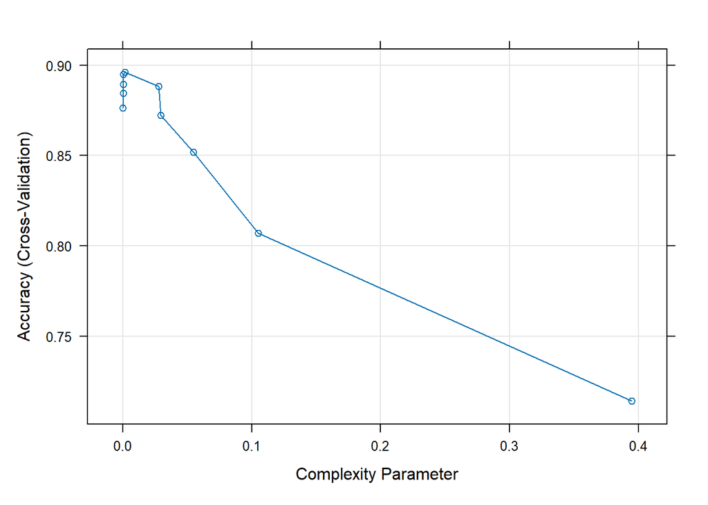

```r
# ============================================================================
# VISUALIZING TUNING RESULTS
# ============================================================================
# Plot shows how model performance changes with different cp values
# Look for the "elbow" where increasing complexity doesn't improve performance
plot(tree_model_cv)  # cp vs Accuracy/Kappa
```

## Random Forest (rf)

```r
# ============================================================================
# RANDOM FOREST MODEL TRAINING
# ============================================================================
# Random Forest builds multiple decision trees and averages their predictions
# Each tree is trained on a bootstrap sample with random feature selection

# THEORETICAL BACKGROUND:
# - Ensemble method (combines multiple models)
# - Reduces overfitting through averaging
# - Handles non-linear relationships well
# - Provides feature importance measures
# - Generally good performance across many datasets
# - Less interpretable than single trees

forest_model_cv <- train(
  diabetes ~ .,           # Predict diabetes using all variables
  data = df,              # Dataset
  method = "rf",          # Method: Random Forest
  trControl = train_control,  # Cross-validation configuration
  tuneLength = 2,         # Number of mtry values to try
  importance = TRUE       # Calculate variable importance
)

# ============================================================================
# HYPERPARAMETER EXPLANATION:
# ============================================================================
# tuneLength = 2: Tests 2 different values of mtry
# mtry: Number of variables randomly sampled at each split
#   - mtry = 1: Use only 1 variable per split (like bagging)
#   - mtry = sqrt(p): Common default (p = number of predictors)
#   - mtry = p: Use all variables (like single tree)

forest_model_cv
```

```
## Random Forest
##
## 9844 samples
##   11 predictor
##    2 classes: '0', '1'
##
## No pre-processing
## Resampling: Cross-Validated (5 fold)
## Summary of sample sizes: 7875, 7875, 7876, 7875, 7875
## Resampling results across tuning parameters:
##
##   mtry  Accuracy   Kappa
##    2    0.8970950  0.7624405
##   11    0.8951649  0.7582252
##
## Accuracy was used to select the optimal model using the largest value.
## The final value used for the model was mtry = 2.
```

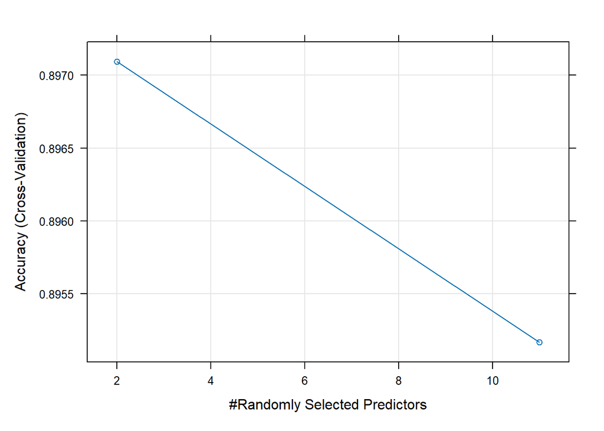

```r
# ============================================================================
# VISUALIZING TUNING RESULTS
# ============================================================================
plot(forest_model_cv)  # mtry vs Accuracy/Kappa
```

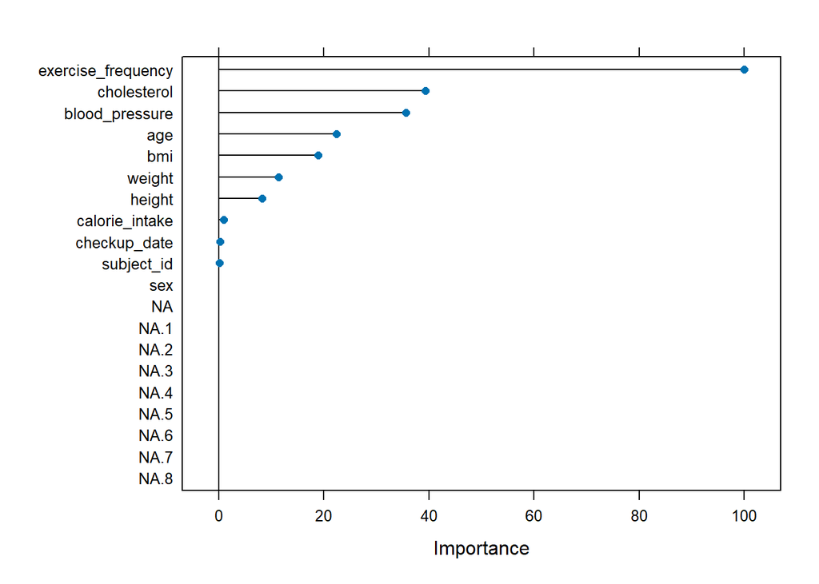

```r
# ============================================================================
# VARIABLE IMPORTANCE ANALYSIS
# ============================================================================
# Shows which variables are most important for predictions
# Higher values = more important variables
varImp(forest_model_cv) %>%
  plot(top = 20)  # Show top 20 most important variables
```